# Lecture 8: t-tests in R

**Learning Objectives**

- Learn how to use R to test for a difference in population means across two groups.
- Reproduce the results that R gives you “by hand” to ensure that you understand where R’s results come from.
- Get mini-quiz credit for attendance and effort/progress.

# Loading the data

We will work with the `nycflights` dataset from the `openintro` package. Please start by loading the required packages and the dataset.

```r
library(tidyverse)
library(openintro)
data(nycflights)
```

Even though this dataset is massive, the `openintro` documentation says that this is a random sample of flights from the population of all flights that departed from NYC in 2013. To see the documentation, you can type `?nycflights` in your console.

# Setting up a research question

I would like to know if flights headed to Denver are more delayed, on average, than flights headed to Los Angeles.

Since my research question relates only to a certain subset of flights in my dataset, my first step is to subset my dataset.

```r
nycflights_subsamp <- nycflights %>%
  filter(dest=="LAX" | dest == "DEN")
```

Next, I can either visually or numerically compare the distribution of flights headed to Los Angeles vs. Denver in my sample. I decided to do this with boxplots, but you could do this however you choose. I came up with the following plot:

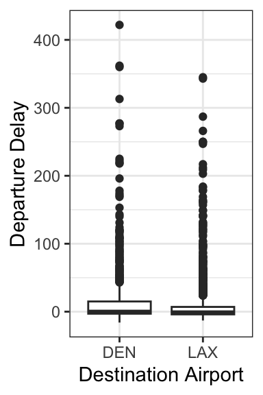

Based on the plot, I can tell that there is a difference in means between flights headed to `LAX` and `DEN` in my sample. However, I cannot tell if this is driven by a true underlying population difference, or just a few unlucky outliers in my sample.

We will use a t-test to get to the bottom of whether or not there is evidence of an underlying population difference here.

# A hypothesis test for a difference in means

Let $\mu_1$ be the population average of delay time for flights headed from NYC to Denver. Let $\mu_2$ be the population average of delay time for flights headed from NYC to Los Angeles. The null hypothesis is
$$H_0: \mu_1 - \mu_2 = 0.$$
We want to see if our sample provides evidence that $\mu_1 - \mu_2 \neq 0$. We can actually get R to do all of this work for us. The following line of code will conduct a t-test to see if `dep_delay` differs by destination airport in our subsetted dataset.

```r
t.test(dep_delay~dest, data=nycflights_subsamp)
```

```
##
##  Welch Two Sample t-test
##
## data:  dep_delay by dest
## t = 3.4621, df = 1118.2, p-value = 0.0005562
## alternative hypothesis: true difference in means between group DEN and group LAX is not equal to 0
## 95 percent confidence interval:
##   2.816468 10.184631
## sample estimates:
## mean in group DEN mean in group LAX
##         16.282609          9.782059
```

When you run this code, it prints out a lot of information for you!

At a high level, we see that the p-value is equal to $0.00055$. You should recognize that this means we *reject* the null hypothesis, and conclude that there is convincing evidence of a difference in means.

But how did `R` come up with this p-value? And what is all of the other information that is printed? We will dive into this below!

# Your task in groups

Your task is to reproduce all of the numbers in the `t.test()` output using the dataset and the theory that we learned in class.

1. Your sample statistic should have the form $\bar{x}_1 - \bar{x}_2$. Find the values of $\bar{x}_1$ and $\bar{x}_2$ directly from your dataset, and save then in `R` to variables called `xbar1` and `xbar2`. Do these show up in the `t.test()` output?
2. R is basing this t-test off of a sampling distribution, whose standard deviation is supposed to be
   $$\sqrt{\frac{\sigma_1^2}{n_1}+\frac{\sigma_2^2}{n_2}}.$$
   However, $\sigma_1$ and $\sigma_2$ are both unknown. Obtain estimates from them using your data, and save the result to variables called `s1` and `s2` in R. While you are at it, also save the appropriate values of $n_1$ and $n_2$ to `R` as `n1` and `n2`. Do any of these numbers appear in the `t.test()` output?
3. Finally, plug all of your estimates in to obtain your estimated standard deviation of your sampling distribution:
   $$\sqrt{\frac{s_1^2}{n_1}+\frac{s_2^2}{n_2}}.$$
   be sure to save this value in `R`, to a variable called `se`. While this number does not appear in the `t.test()` printout, you should check to see if your answer matches the number printed by the code: `t.test(dep_delay~dest, data=nycflights_subsamp)$stderr`.
4. The `t.test()` output prints out `t=3.46`. Based on what you have calculated so far, reproduce the number 3.46. On your mini quiz, explain briefly what you did.
5. When we do a two-sample t-test for a difference in means and the two samples have different sizes and different standard deviations, a complicated formula tells us how many degrees of freedom our t-test has. In this case, I would argue that we really don’t need to worry about the exact degrees of freedom for our test. In the context of this dataset, why might I argue that we don’t need to worry about the exact degrees of freedom?
6. Use `R` to reproduce the p-value given by the `t.test()` output. You may *either* use the `pt()` function and tell it that `df=1118.2`, or you may simply use `pnorm()`. You can even try both and compare your answers. On your mini quiz, briefly explain how you computed the p-value. A picture might help.
7. Use `R` to reproduce the confidence interval printed by ``t.test()`. Once again, you may use either a `t`-multiplier (with the appropriate degrees of freedom) or a `z`-multiplier. On your mini quiz, explain briefly how you did this, and interpret your confidence interval in your own words.